# Práctica 1: Regresión en Drosophila

Curso de Genética Cuantitativa Evolutiva

21 de febrero de 2025

# 1 Introducción

En este ejercicio, estudiaremos la **heredabilidad** de un rasgo (por ejemplo, longitud de ala) en **Drosophila melanogaster**, utilizando **regresiones simples**.

- `mo`: Fenotipo (p. ej., longitud de ala) en la madre.
- `fa`: Fenotipo en el padre.
- `midparent`: Promedio entre `mo` y `fa`.
- `off`: Fenotipo de la descendencia (por ejemplo, el promedio de la longitud de ala en la progenie).

La **pendiente** de la regresión `off ~ midparent` se asocia, en genética cuantitativa, con (h^2). También podemos aproximar h^2 al analizar por separado `off ~ mo` o `off ~ fa`.

## 1.1 Objetivos de la Práctica

1. **Familiarizarse** con la manipulación de datos que incluyan `mo`, `fa`, `midparent`, `off`.
2. **Realizar** tres regresiones lineales para estimar la heredabilidad:
   - `off ~ midparent`
   - `off ~ mo`
   - `off ~ fa`
3. **Interpretar** las pendientes de regresión y relacionarlos con la heredabilidad (en un escenario simplificado).

## 1.2 Organización y Horario

- **Horario:** Lunes, 15:00 - 18:00
- **Metodología de Trabajo:**
  - Trabajo individual.
  - Asesoría de los docentes.
  - Discusión grupal al final.

## 1.3 Recursos Necesarios

- **R** (preferentemente RStudio).
- **Paquetes** `dplyr` y `ggplot2`.
- **Datos** en las columnas `mo`, `fa`, `midparent`, `off`, ya sean reales o simulados.

# 2 Configuración en R

```r
# Instala dplyr y ggplot2 si no los tienes:
# install.packages(c("dplyr", "ggplot2"))

library(dplyr)
library(ggplot2)
theme_set(theme_minimal())
```

# 3 Carga y Preparación de Datos

## 3.1 Datos Reales o Simulados

### 3.1.1 Opción A: Cargar desde CSV

```r
# datos <- read.csv("practica1.csv")
# head(datos)
# str(datos)
```

Asegúrate de que contenga al menos las columnas: `mo`, `fa`, `midparent`, `off`.

### 3.1.2 Opción B: Simulación de Datos (Ejemplo)

```r
set.seed(123)
n <- 100

# Fenotipos de madre (mo) y padre (fa)
mo <- rnorm(n, mean = 10, sd = 2)
fa <- rnorm(n, mean = 10, sd = 2)

# Calculamos midparent
midparent <- (mo + fa) / 2

# Heredabilidad hipotética
h2 <- 0.4

# Error ambiental
error <- rnorm(n, mean = 0, sd = 1.5)

# off = fenotipo de la descendencia (promedio)
off <- h2 * midparent + error

# Creamos el data frame
datos <- data.frame(mo, fa, midparent, off)

head(datos)
```

```
##          mo        fa midparent      off
## 1  8.879049  8.579187  8.729118 6.789863
## 2  9.539645 10.513767 10.026706 5.979302
## 3 13.117417  9.506616 11.312016 4.127089
## 4 10.141017  9.304915  9.722966 4.703977
## 5 10.258575  8.096763  9.177669 3.049558
## 6 13.430130  9.909945 11.670037 3.953645
```

```r
str(datos)
```

```
## 'data.frame':    100 obs. of  4 variables:
##  $ mo       : num  8.88 9.54 13.12 10.14 10.26 ...
##  $ fa       : num  8.58 10.51 9.51 9.3 8.1 ...
##  $ midparent: num  8.73 10.03 11.31 9.72 9.18 ...
##  $ off      : num  6.79 5.98 4.13 4.7 3.05 ...
```

## 3.2 Exploración Rápida

```r
summary(datos)
```

```
##        mo               fa           midparent           off
##  Min.   : 5.382   Min.   : 5.894   Min.   : 7.067   Min.   :1.076
##  1st Qu.: 9.012   1st Qu.: 8.398   1st Qu.: 9.015   1st Qu.:3.096
##  Median :10.124   Median : 9.548   Median :10.052   Median :4.141
##  Mean   :10.181   Mean   : 9.785   Mean   : 9.983   Mean   :4.174
##  3rd Qu.:11.384   3rd Qu.:10.936   3rd Qu.:10.969   3rd Qu.:5.038
##  Max.   :14.375   Max.   :16.482   Max.   :12.880   Max.   :7.915
```

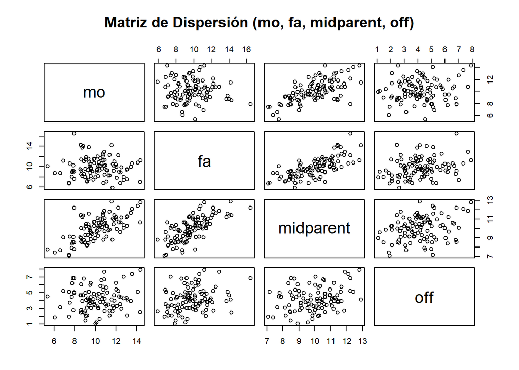

```r
pairs(datos, main = "Matriz de Dispersión (mo, fa, midparent, off)")
```

# 4 Regresiones para Estimar Heredabilidad

## 4.1 off ~ midparent

Teóricamente, la pendiente de este modelo se asocia a h^2.

```r
modelo_midparent <- lm(off ~ midparent, data = datos)
summary(modelo_midparent)
```

```
##
## Call:
## lm(formula = off ~ midparent, data = datos)
##
## Residuals:
##     Min      1Q  Median      3Q     Max
## -2.8465 -0.9671 -0.2155  0.9886  3.1487
##
## Coefficients:
##             Estimate Std. Error t value Pr(>|t|)
## (Intercept)   0.9283     1.1149   0.833  0.40707
## midparent     0.3251     0.1108   2.935  0.00415 **
## ---
## Signif. codes:  0 '***' 0.001 '**' 0.01 '*' 0.05 '.' 0.1 ' ' 1
##
## Residual standard error: 1.429 on 98 degrees of freedom
## Multiple R-squared:  0.08082,    Adjusted R-squared:  0.07144
## F-statistic: 8.616 on 1 and 98 DF,  p-value: 0.004151
```

### 4.1.1 Visualización

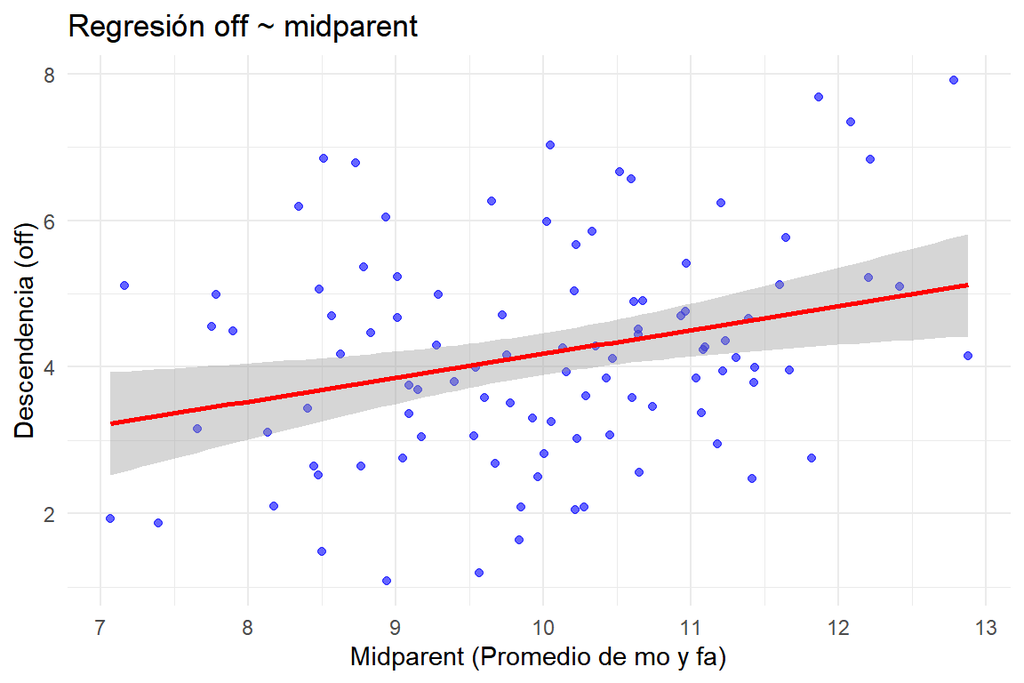

```r
ggplot(datos, aes(x = midparent, y = off)) +
  geom_point(alpha = 0.6, color = "blue") +
  geom_smooth(method = "lm", se = TRUE, color = "red") +
  labs(title = "Regresión off ~ midparent",
       x = "Midparent (Promedio de mo y fa)",
       y = "Descendencia (off)")
```

## 4.2 off ~ mo (Madre)

```r
modelo_madre <- lm(off ~ mo, data = datos)
summary(modelo_madre)
```

```
##
## Call:
## lm(formula = off ~ mo, data = datos)
##
## Residuals:
##     Min      1Q  Median      3Q     Max
## -3.0831 -1.0439 -0.1128  0.8750  3.4479
##
## Coefficients:
##             Estimate Std. Error t value Pr(>|t|)
## (Intercept)  3.27091    0.84334   3.879  0.00019 ***
## mo           0.08869    0.08155   1.088  0.27945
## ---
## Signif. codes:  0 '***' 0.001 '**' 0.01 '*' 0.05 '.' 0.1 ' ' 1
##
## Residual standard error: 1.481 on 98 degrees of freedom
## Multiple R-squared:  0.01193,    Adjusted R-squared:  0.001843
## F-statistic: 1.183 on 1 and 98 DF,  p-value: 0.2795
```

### 4.2.1 Visualización

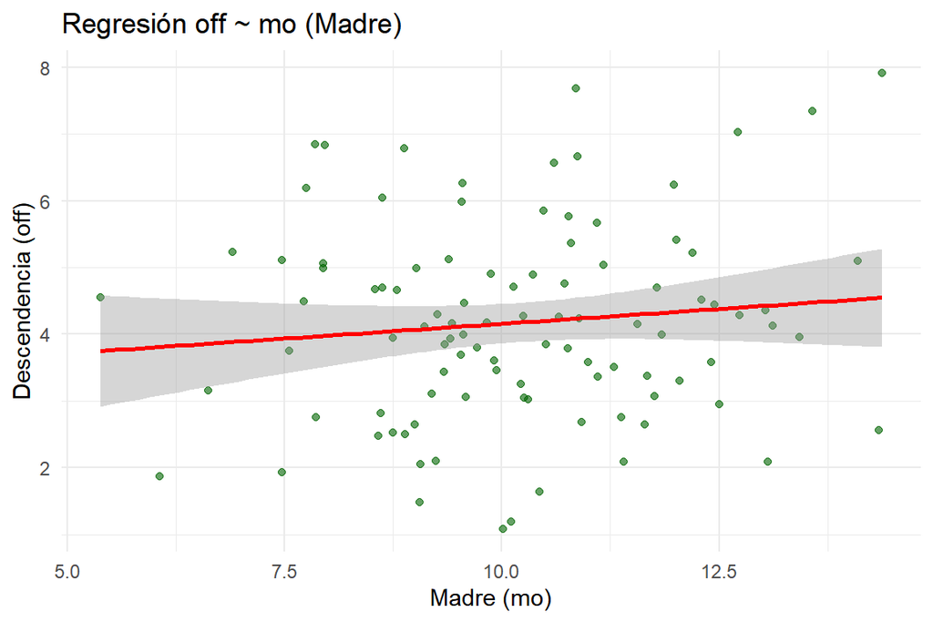

```r
ggplot(datos, aes(x = mo, y = off)) +
  geom_point(alpha = 0.6, color = "darkgreen") +
  geom_smooth(method = "lm", se = TRUE, color = "red") +
  labs(title = "Regresión off ~ mo (Madre)",
       x = "Madre (mo)",
       y = "Descendencia (off)")
```

## 4.3 off ~ fa (Padre)

```r
modelo_padre <- lm(off ~ fa, data = datos)
summary(modelo_padre)
```

```
##
## Call:
## lm(formula = off ~ fa, data = datos)
##
## Residuals:
##     Min      1Q  Median      3Q     Max
## -2.8205 -0.9614 -0.2301  0.7752  3.4397
##
## Coefficients:
##             Estimate Std. Error t value Pr(>|t|)
## (Intercept)  2.08792    0.74183   2.815  0.00590 **
## fa           0.21318    0.07439   2.866  0.00509 **
## ---
## Signif. codes:  0 '***' 0.001 '**' 0.01 '*' 0.05 '.' 0.1 ' ' 1
##
## Residual standard error: 1.431 on 98 degrees of freedom
## Multiple R-squared:  0.07732,    Adjusted R-squared:  0.0679
## F-statistic: 8.212 on 1 and 98 DF,  p-value: 0.005092
```

### 4.3.1 Visualización

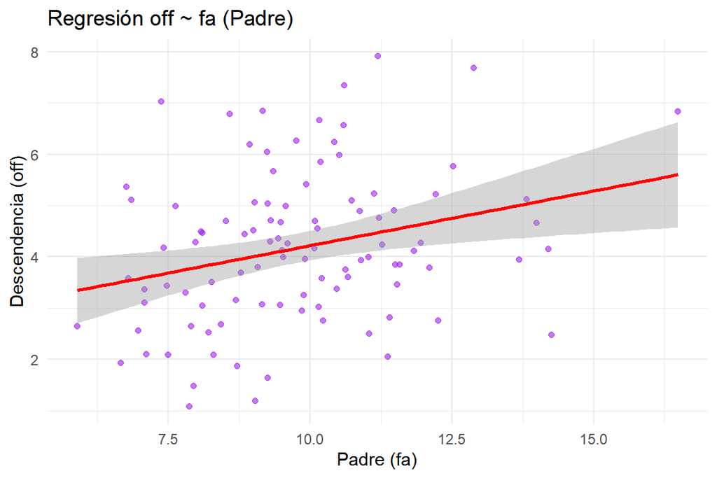

```r
ggplot(datos, aes(x = fa, y = off)) +
  geom_point(alpha = 0.6, color = "purple") +
  geom_smooth(method = "lm", se = TRUE, color = "red") +
  labs(title = "Regresión off ~ fa (Padre)",
       x = "Padre (fa)",
       y = "Descendencia (off)")
```

# 5 Interpretación

# 6 Discusión de los Resultados

1. **Pendiente**:
   - `off ~ midparent`: la pendiente se asocia a h^2.
   - `off ~ mo` o `off ~ fa`: la pendiente se asocia a la mitad de h^2.
2. **Significancia**: si la p es < 0.05, la relación es estadísticamente confiable.
3. **Limitaciones**: este método asume un modelo muy simple y no corrige efectos maternos ambientales, epistasia, etc.

# 7 Conclusiones

- Se introdujo la **historia en Drosophila** para un rasgo (ej. longitud de ala).
- Se mostraron **tres regresiones**: `off ~ midparent`, `off ~ mo`, `off ~ fa`.
- Las pendientes aproximan la heredabilidad.
- Se invita a **discutir** la plausibilidad de estos resultados y las simplificaciones del modelo.

## 7.1 Lecturas Recomendadas

- *Introduction to Quantitative Genetics* (Falconer & Mackay).
- *Genetics and Analysis of Quantitative Traits* (Lynch & Walsh).
- Sitio oficial de R: https://cran.r-project.org/